# Neehal Tumma

Neehal Tumma

Hi, I'm Neehal! I am a second-year PhD student at [MIT CSAIL](https://www.csail.mit.edu/), advised by [Prof. Daniela Rus](https://danielarus.csail.mit.edu/). I also work at [Liquid AI](https://www.liquid.ai/) on scaling efficient foundation models.

My research interests broadly lie in architecture design for sequence modeling, particularly LLMs. Within this space, I primarily focus on recurrent architectures as alternatives to attention-based ones. I am interested in exploring these recurrent primitives in various settings, including test-time training, continual learning, and efficient long-context modeling. My broader goal is to make test-time learning efficient and widely deployable, enabling models to continually adapt to new experiences without large-scale retraining.

I graduated from [Harvard](https://www.harvard.edu/) in 2024 with an SM in Computer Science and an AB in Mathematics and Computer Science. During my undergrad, I was fortunate enough to work with [Prof. Nir Shavit](https://www.csail.mit.edu/person/nir-shavit) and [Prof. Finale Doshi-Velez](https://finale.seas.harvard.edu/).

I'm always happy to connect with researchers interested in collaborating, as well as MIT undergraduates interested in UROP projects. Feel free to reach out if our research interests overlap!

Email / [Google Scholar](https://scholar.google.com/citations?hl=en&user=QzU05TwAAAAJ&view_op=list_works&sortby=pubdate) / [Twitter](https://x.com/ntumm120) / [GitHub](https://github.com/ntumm120) / [LinkedIn](https://www.linkedin.com/in/neehal-tumma-82a2141a8/)

[figure not shown]

Recent News

| **Nov 2026** | [ParaTTT](https://arxiv.org/abs/2610.38255) preprint released! |
| --- | --- |
| **Oct 2026** | New quantization preprints: [LinQuant](https://arxiv.org/abs/2610.39418) and [Quantizing Recurrent Language Models Is Easier Than You Think](https://arxiv.org/abs/2611.01864)! |
| **May 2026** | [Preconditioned DeltaNet](https://arxiv.org/abs/2604.21100) paper accepted at ICML 2026! |
| **Dec 2025** | [LFM2](https://arxiv.org/pdf/2511.23404) technical report released! |
| **Sep 2025** | Started my PhD at [MIT EECS](https://www.eecs.mit.edu/), doing research on efficient architectures! |
| **June 2025** | [Connectomics](https://www.sciencedirect.com/science/article/abs/pii/S0893608025005684) paper published in Neural Networks journal! |
| **May 2025** | [Effective state-size](https://arxiv.org/pdf/2504.19561) paper accepted at ICML 2025! |
| **May 2024** | Graduated from [Harvard](https://www.harvard.edu/) with an AB/SM in Computer Science and Math! |
| **Mar 2024** | Started working at [Liquid AI](https://www.liquid.ai/) on pretraining edge-aware foundation models! |
| **Jan 2024** | [Low-rank and sparse recurrences](https://arxiv.org/pdf/2310.03915.pdf) paper accepted at ICLR 2024 as a Spotlight! |

| Publications |
| --- |

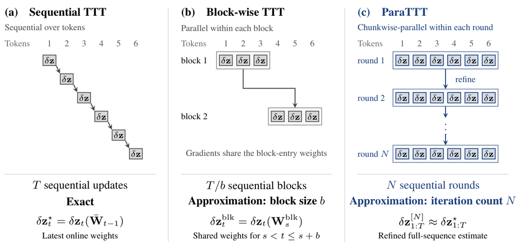

ParaTTT: Parallelizing Test-Time Training Layers with Deep Memories  
Noel Loo*, **Neehal Tumma***, T. Konstantin Rusch, Mathias Lechner, Alexander Amini, Daniela Rus  
*Preprint*, 2026  
[paper](https://arxiv.org/abs/2610.38255) / [code](https://github.com/ntumm120/paraTTT)

We introduce ParaTTT, an algorithm for parallelizing test-time training layers with deep nonlinear memories through iterative refinement. The exact online recurrence is a fixed point of the iteration. With two refinement steps, ParaTTT trains 4.9× faster than TTT-MLP at 340M scale while improving recall over linear recurrent models.

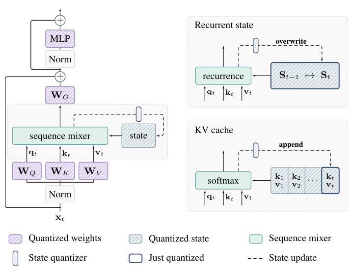

Quantizing Recurrent Language Models Is Easier Than You Think  
Philipp Nazari*, **Neehal Tumma***, Daniela Rus, T. Konstantin Rusch  
*Preprint*, 2026  
[paper](https://arxiv.org/abs/2611.01864) / [code](https://github.com/camail-official/LoReS) / [tweet](https://x.com/philna00/status/2123478487658811826) / [blog](https://phnazari.github.io/blog/2026/lores/)

We show that decayed recurrent models develop weaker residual outliers than softmax Transformers, making their weights and activations easier to quantize. For the recurrent state, we introduce LoReS, combining scale grouping, decay-based mixed precision, and stochastic rounding to support robust 8-bit state quantization and faster decoding in vLLM.

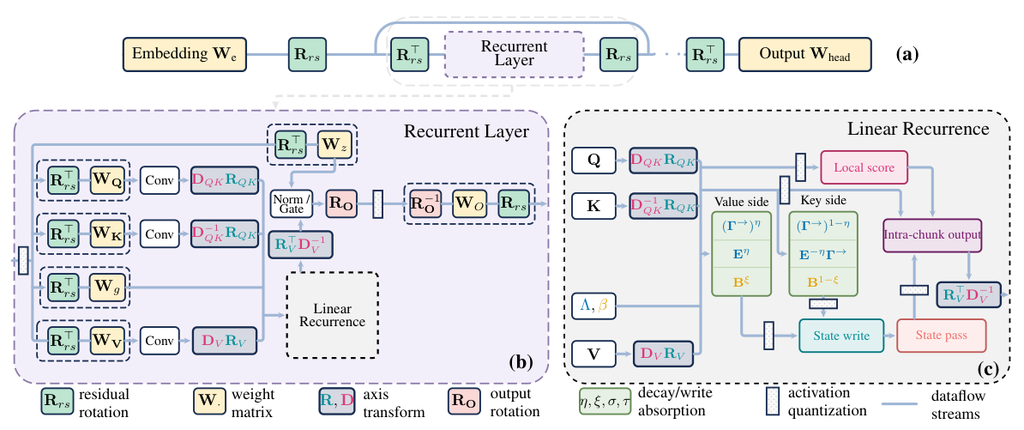

LinQuant: Functional Invariances for Low-Precision Linear Recurrences  
**Neehal Tumma***, Philipp Nazari*, Rohan Cherukuri, Daniela Rus, T. Konstantin Rusch  
*Preprint*, 2026  
[paper](https://arxiv.org/abs/2610.39418) / [code](https://github.com/ntumm120/LinQuant) / [tweet](https://x.com/ntumm120/status/2118400198539927994)

We identify seven functional invariances that preserve the full-precision computation of linear recurrences while making their operands easier to quantize. LinQuant uses these transformations to improve low-precision prefill across recurrent architectures, improving perplexity at matched latency on Mamba-2 and Nemotron-H.

[figure not shown]

Preconditioned DeltaNet: Curvature-aware Sequence Modeling for Linear Recurrences  
**Neehal Tumma***, Noel Loo*, Daniela Rus  
*ICML*, 2026  
[paper](https://arxiv.org/abs/2604.21100) / [code](https://github.com/ntumm120/preconditioned-deltanet) / [tweet](https://x.com/ntumm120/status/2048839632675033567)

We show that with least-squares preconditioning, DeltaNet and linear attention reduce to the same recurrence. Using this insight, we introduce preconditioned variants of DeltaNet (PDN), Gated DeltaNet (PGDN), and Kimi Delta Attention (PKDA), demonstrating gains across synthetic recall benchmarks and language modeling at the 340M and 1B scale.

[figure not shown]

LFM2 Technical Report  
Liquid AI Team  
*arXiv*, 2025  
[paper](https://arxiv.org/pdf/2511.23404) / [tweet](https://x.com/liquidai/status/1995493302993358949)

We introduce LFM2, a family of compact foundation models (350M–8.3B parameters) optimized for edge deployment. Using hardware-in-the-loop architecture search, LFM2 achieves up to 2x faster prefill and decode on CPUs compared to similarly sized models, with extensions to vision-language, speech, and retrieval.

[figure not shown]

Quantifying Memory Utilization with Effective State-Size  
Rom N. Parnichkun*, **Neehal Tumma***, Armin W. Thomas, Alessandro Moro, Qi An, Taiji Suzuki, Atsushi Yamashita, Michael Poli, Stefano Massaroli  
*ICML*, 2025  
[paper](https://arxiv.org/pdf/2504.19561) / [tweet](https://x.com/romu_nishi/status/1920853034357453108)

We introduce effective state-size (ESS), a principled metric grounded in signal processing and control theory for quantifying how sequence models utilize memory. ESS provides interpretable insights into memory dynamics across attention, convolutions, and recurrent architectures, enabling improved initialization, regularization, and distillation.

[figure not shown]

A connectomics-driven analysis reveals novel characterization of border regions in mouse visual cortex  
**Neehal Tumma***, Linghao Kong*, Shashata Sawmya, Tony Tong Wang, Nir Shavit  
*Neural Networks*, 2025  
[paper](https://www.sciencedirect.com/science/article/abs/pii/S0893608025005684)

We propose a statistical sliding window framework for analyzing neural connectivity in large-scale connectomics datasets using both the connectivity graph and functional activations. Applied to the MICrONS dataset, we find that the V1-RL border region exhibits greater synaptic connectivity and more synchronous activity, acting as a bridge between visual areas.

[figure not shown]

Leveraging Low-Rank and Sparse Recurrent Connectivity for Robust Closed-Loop Control  
**Neehal Tumma**, Mathias Lechner, Noel Loo, Ramin Hasani, Daniela Rus  
*ICLR*, 2024 (Spotlight, top 5% of submissions)  
[paper](https://arxiv.org/pdf/2310.03915.pdf) / [tweet](https://x.com/ramin_m_h/status/1750595741041525236)

We explore how the recurrent connectivity of RNNs, parameterized by rank and sparsity, influences robustness in closed-loop control. We show that low-rank, sparse connectivity induces desirable network dynamics, enabling closed-form continuous-time networks (CfCs) with fewer parameters to outperform their full-rank counterparts under distribution shift.

[figure not shown]

A Joint Learning Approach for Semi-supervised Neural Topic Modeling  
Jeffrey Chiu*, Rajat Mittal*, **Neehal Tumma***, Abhishek Sharma, Finale Doshi-Velez  
*ACL SPNLP*, 2022  
[paper](https://aclanthology.org/2022.spnlp-1.5.pdf)

We introduce the Label-Indexed Neural Topic Model (LI-NTM), the first effective upstream semi-supervised neural topic model. LI-NTM outperforms existing neural topic models in document reconstruction, with the strongest results in low labeled data regimes.